# Praca_domowa_4

Konrad Welkier

8 listopada 2019

### Oryginalny wykres

Oryginalny wykres pochodzi z artykułu pt. “Alior odbija od dna. Wyniki najlepsze w tym roku. Firmy dały zarobić”, który można znaleźć poniżej: (https://www.money.pl/gielda/alior-odbija-od-dna-wyniki-najlepsze-w-tym-roku-firmy-daly-zarobic-6442778158815361a.html).

Sam wykres natomiast zamieszczam poniżej:

[figure not shown]

Głównym zarzutem, który wnoszę do powyższego obrazu jest ucięcie osi OY bardzo blisko minimalnej wartości osiągniętej przez cenę akcji Alior Banku, co ma sugerować, że istotnie “odbiła się ona od dna”. Ponadto przedstawiony został bardzo krótki okres, więc ciężko nawet stwierdzić w jak długim okresie czasu cena akcji Alior Banku malała. Obie te nieścisłości naprawia mój pierwszy wykres:

## Pierwszy wykres

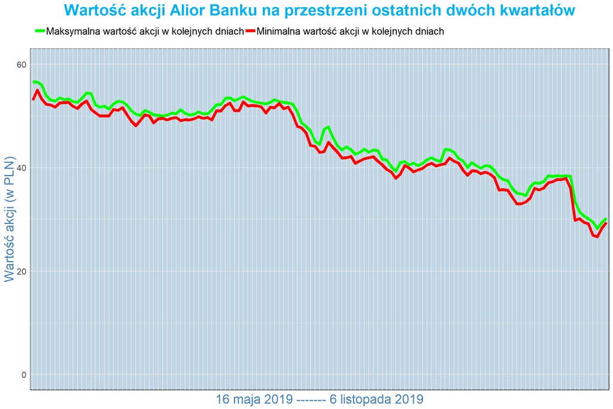

Uważam, że mój pierwszy wykres pokazuje znacznie szersze spektrum interesującego nas zagadnienia i robi to w sposób znacząco bardziej obiektywny. Jednkże jeszcze większą obiektywność zyskamy jeśli porównamy, w tym samym okresie czasu, ceny akcji Alior Banku z cenami akcji WIG-BANKI, czyli indeksu giełdowego, do którego akcje Alior Banku należą. Oczywiście ceny akcji każdego banku mogą należeć liczbowo do bardzo różnych przedziałów, więc pozwoliłem sobie uśrednić otrzymane pomiary (dane, z których korzystamy dotyczą każdego banku należącego do WIG-BANKI z osobna, a nie całego indeksu giełdowego na raz).

## Drugi wykres

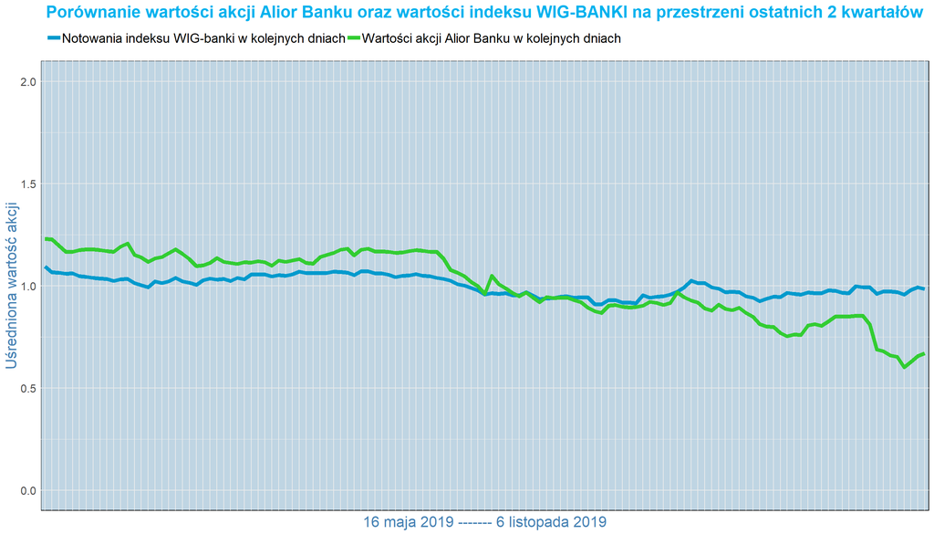